# Анализ книжной базы данных (проект по SQL)

В связи с ковидными ограничениями больше людей начали читать книги. Поэтому наша компания решила быть на волне и купила крупный сервис для чтения книг по подписке.

Необходимо проанализировать базу данных, в которой содержится информация о книгах, издательствах, авторах, а также пользовательские обзоры книг.

Цель: **предоставить данные, которые помогут сформулировать ценностное предложение для нового продукта.**

### Схема данных:

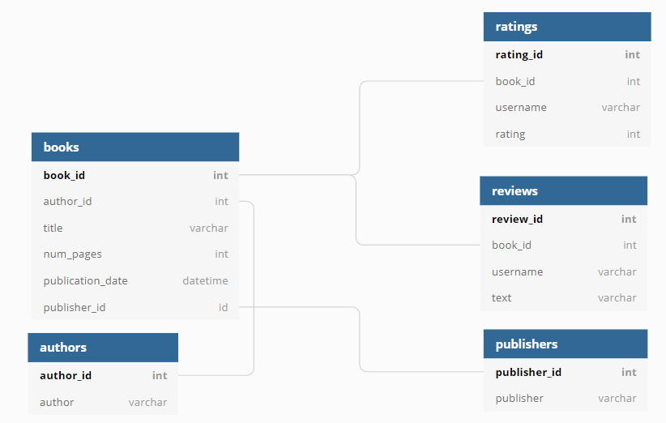

### Задачи:

- Посчитать, сколько книг вышло после 1 января 2000 года;
- Для каждой книги посчитать количество обзоров и среднюю оценку;
- Определить издательство, которое выпустило наибольшее число книг толще 50 страниц;
- Определить автора с самой высокой средней оценкой книг — учитывать только книги с 50 и более оценками;
- Посчитать среднее количество обзоров от пользователей, которые поставили больше 48 оценок.

## Подключение к БД и просмотр таблиц

```python
!pip install psycopg2-binary

import pandas as pd
from sqlalchemy import text, create_engine
from IPython.display import display
```

```python
# устанавливаем параметры
db_config = {'user': 'praktikum_student',
             'pwd': 'Sdf4$2;d-d30pp',
             'host': 'rc1b-wcoijxj3yxfsf3fs.mdb.yandexcloud.net',
             'port': 6432,
             'db': 'data-analyst-final-project-db'}

connection_string = 'postgresql://{user}:{pwd}@{host}:{port}/{db}'.format(**db_config)

# сохраняем коннектор
engine = create_engine(connection_string, connect_args={'sslmode':'require'})
con = engine.connect()
```

```python
query = '''SELECT * FROM {} LIMIT 5'''

for i in ['books', 'authors', 'ratings', 'reviews', 'publishers']:
    df = pd.io.sql.read_sql(sql=text(query.format(i)), con = con)
    print(i)
    display(df)
```

```
books
```

|  | book_id | author_id | title | num_pages | publication_date | publisher_id |
| --- | --- | --- | --- | --- | --- | --- |
| 0 | 1 | 546 | 'Salem's Lot | 594 | 2005-11-01 | 93 |
| 1 | 2 | 465 | 1 000 Places to See Before You Die | 992 | 2003-05-22 | 336 |
| 2 | 3 | 407 | 13 Little Blue Envelopes (Little Blue Envelope... | 322 | 2010-12-21 | 135 |
| 3 | 4 | 82 | 1491: New Revelations of the Americas Before C... | 541 | 2006-10-10 | 309 |
| 4 | 5 | 125 | 1776 | 386 | 2006-07-04 | 268 |

```
authors
```

|  | author_id | author |
| --- | --- | --- |
| 0 | 1 | A.S. Byatt |
| 1 | 2 | Aesop/Laura Harris/Laura Gibbs |
| 2 | 3 | Agatha Christie |
| 3 | 4 | Alan Brennert |
| 4 | 5 | Alan Moore/David Lloyd |

```
ratings
```

|  | rating_id | book_id | username | rating |
| --- | --- | --- | --- | --- |
| 0 | 1 | 1 | ryanfranco | 4 |
| 1 | 2 | 1 | grantpatricia | 2 |
| 2 | 3 | 1 | brandtandrea | 5 |
| 3 | 4 | 2 | lorichen | 3 |
| 4 | 5 | 2 | mariokeller | 2 |

```
reviews
```

|  | review_id | book_id | username | text |
| --- | --- | --- | --- | --- |
| 0 | 1 | 1 | brandtandrea | Mention society tell send professor analysis. ... |
| 1 | 2 | 1 | ryanfranco | Foot glass pretty audience hit themselves. Amo... |
| 2 | 3 | 2 | lorichen | Listen treat keep worry. Miss husband tax but ... |
| 3 | 4 | 3 | johnsonamanda | Finally month interesting blue could nature cu... |
| 4 | 5 | 3 | scotttamara | Nation purpose heavy give wait song will. List... |

```
publishers
```

|  | publisher_id | publisher |
| --- | --- | --- |
| 0 | 1 | Ace |
| 1 | 2 | Ace Book |
| 2 | 3 | Ace Books |
| 3 | 4 | Ace Hardcover |
| 4 | 5 | Addison Wesley Publishing Company |

**Вывод:** Данные соответствуют указанной структуре

## Задача 1

```python
query_q1 = '''SELECT COUNT(title) AS total
           FROM books
           WHERE CAST(publication_date AS TIMESTAMP) > '2000-01-01'
           '''

pd.io.sql.read_sql(sql=text(query_q1), con = con)
```

|  | total |
| --- | --- |
| 0 | 819 |

819 книг вышло после 1 января 2000 года

## Задача 2

```python
query_q2 = '''SELECT b.book_id,
           b.title,
           ra.average_rating,
           re.num_reviews
           FROM books as b
           LEFT OUTER JOIN
              (SELECT book_id,
               AVG(rating) AS average_rating
               FROM ratings
               GROUP BY book_id) AS ra ON ra.book_id = b.book_id
           LEFT OUTER JOIN
               (SELECT book_id,
                COUNT(*) as num_reviews
                FROM reviews
                GROUP BY book_id) AS re ON re.book_id = b.book_id
           '''

df = pd.io.sql.read_sql(sql=text(query_q2), con = con)
display(df)
```

|  | book_id | title | average_rating | num_reviews |
| --- | --- | --- | --- | --- |
| 0 | 652 | The Body in the Library (Miss Marple #3) | 4.500000 | 2.0 |
| 1 | 273 | Galápagos | 4.500000 | 2.0 |
| 2 | 51 | A Tree Grows in Brooklyn | 4.250000 | 5.0 |
| 3 | 951 | Undaunted Courage: The Pioneering First Missio... | 4.000000 | 2.0 |
| 4 | 839 | The Prophet | 4.285714 | 4.0 |
| ... | ... | ... | ... | ... |
| 995 | 64 | Alice in Wonderland | 4.230769 | 4.0 |
| 996 | 55 | A Woman of Substance (Emma Harte Saga #1) | 5.000000 | 2.0 |
| 997 | 148 | Christine | 3.428571 | 3.0 |
| 998 | 790 | The Magicians' Guild (Black Magician Trilogy #1) | 3.500000 | 2.0 |
| 999 | 828 | The Plot Against America | 3.000000 | 2.0 |

1000 rows × 4 columns

Полученный датафрейм содержит количество обзоров и среднюю оценку для каждой книги

## Задача 3

```python
query_q3 = '''SELECT p.publisher,
           tmp.num
           FROM publishers as p
           RIGHT OUTER JOIN (SELECT publisher_id,
                              COUNT(book_id) AS num
                              FROM books
                              WHERE num_pages > 50
                              GROUP BY publisher_id
                              ORDER BY COUNT(book_id) DESC
                              LIMIT 1) AS tmp ON tmp.publisher_id = p.publisher_id
       '''

pd.io.sql.read_sql(sql=text(query_q3), con = con)
```

|  | publisher | num |
| --- | --- | --- |
| 0 | Penguin Books | 42 |

Penguin Books выпустило наибольшее число книг толще 50 страниц

## Задача 4

```python
query_q4 = '''SELECT a.author,
              AVG(r.rating) AS average_rating
           FROM books AS b
           LEFT OUTER JOIN authors AS a ON a.author_id = b.author_id
           RIGHT OUTER JOIN ratings AS r ON r.book_id = b.book_id
           WHERE b.book_id IN (SELECT book_id
                               FROM ratings
                               GROUP BY book_id
                               HAVING COUNT(*) >= 50)
           GROUP BY a.author
           ORDER BY average_rating DESC
           LIMIT 1
           '''

pd.io.sql.read_sql(sql=text(query_q4), con = con)
```

|  | author | average_rating |
| --- | --- | --- |
| 0 | J.K. Rowling/Mary GrandPré | 4.287097 |

J.K. Rowling - автор с самой высокой средней оценкой книг, учитывая книги с 50 и более оценками

## Задача 5

```python
query_q5 = '''SELECT AVG(num)
           FROM (SELECT COUNT(*) AS num
                 FROM reviews
                 WHERE username IN (SELECT username
                                    FROM ratings
                                    GROUP BY username
                                    HAVING COUNT(rating_id) > 48)
                 GROUP BY username) AS tmp
       '''

pd.io.sql.read_sql(sql=text(query_q5), con = con)
```

|  | avg |
| --- | --- |
| 0 | 24.0 |

Среднее количество обзоров от пользователей, которые поставили больше 48 оценок, равно 24

## Рекомендации:

- Использовать данные об отзывах и средних оценках для формирования рекомендаций пользователям. Чтобы повысить удовлетворенность пользователей, можно рекомендовать книги с высокими оценками и большим количеством отзывов
- Предлагать акции и спецпредложения на произведения J.K. Rowling. Также можно включить ее произведения в подписку
- Можно создать систему вознаграждения для пользователей, часто оставляющих отзывы. Например, предлагать специальные бонусы/скидки за активное участие.